# BMIN503/EPID600 Project COVID-19 and its impact in Biotechnology and Medical Device Industry

###ZBH

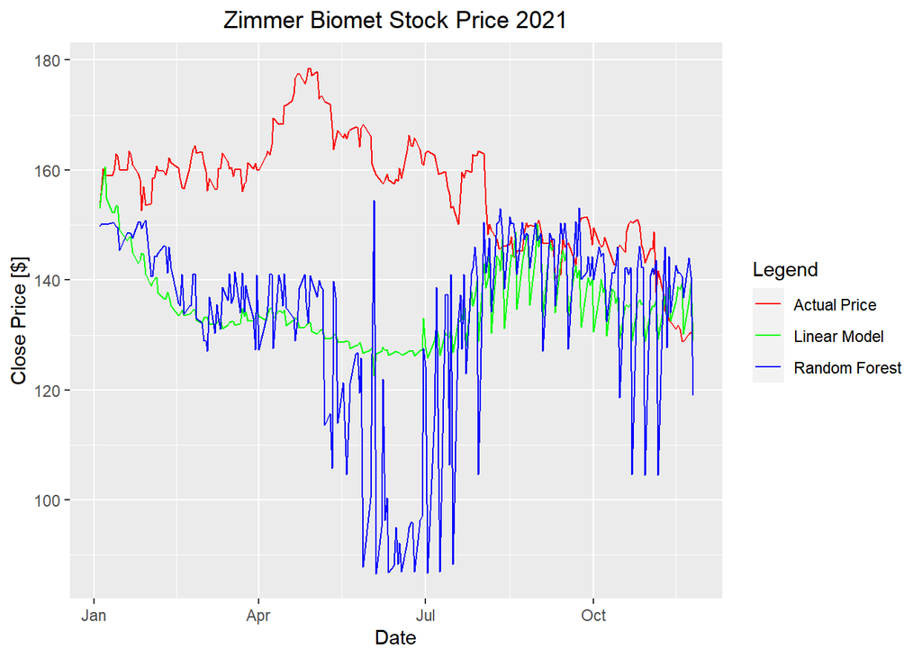

```r
#Linear
ZBH_2021_case_pred = predict(ZBH_model_A, newdata = ZBH_2021_case)
ZBH_2021_case$LPredict = 0
for(i in 1:nrow(ZBH_2021_case)){
  ZBH_2021_case$LPredict[i] = ZBH_2021_case_pred[i]
}

ZBH_2021_death_pred = predict(ZBH_model_B, newdata = ZBH_2021_death)
ZBH_2021_death$LPredict = 0
for(i in 1:nrow(ZBH_2021_death)){
  ZBH_2021_death$LPredict[i] = ZBH_2021_death_pred[i]
}
#RF
ZBH_2021_case_rf = predict(ZBH_cforest, newdata = ZBH_2021_case)
ZBH_2021_case$RfPredict = 0
for(i in 1:nrow(ZBH_2021_case)){
  ZBH_2021_case$RfPredict[i] = ZBH_2021_case_rf[i]
}

ZBH_2021_death_rf = predict(ZBH_dforest, newdata = ZBH_2021_death)
ZBH_2021_death$RfPredict = 0
for(i in 1:nrow(ZBH_2021_death)){
  ZBH_2021_death$RfPredict[i] = ZBH_2021_death_rf[i]
}


ZBH_2021_case$Date = as.Date(ZBH_2021_case$Date)
ZBH_2021_case = na.omit(ZBH_2021_case)
ZBH_2021_death$Date = as.Date(ZBH_2021_death$Date)
ZBH_2021_death = na.omit(ZBH_2021_death)
colors <- c("Actual Price" = "red", "Linear Model" = "green", "Random Forest" = "blue")

ggplot()+
   geom_line(aes(Date,Close,group=1, color ="Actual Price"),data=ZBH_2021_case )+geom_line(aes(Date,LPredict,group=1, color = "Linear Model"),data=ZBH_2021_case)+geom_line(aes(Date,RfPredict,group=1, color =  "Random Forest"),data=ZBH_2021_case)+ggtitle("Zimmer Biomet Stock Price 2021") + theme(plot.title = element_text(hjust = 0.5)) + labs(x = "Date", y = "Close Price [$]",color = "Legend") + scale_color_manual(values = colors)
```

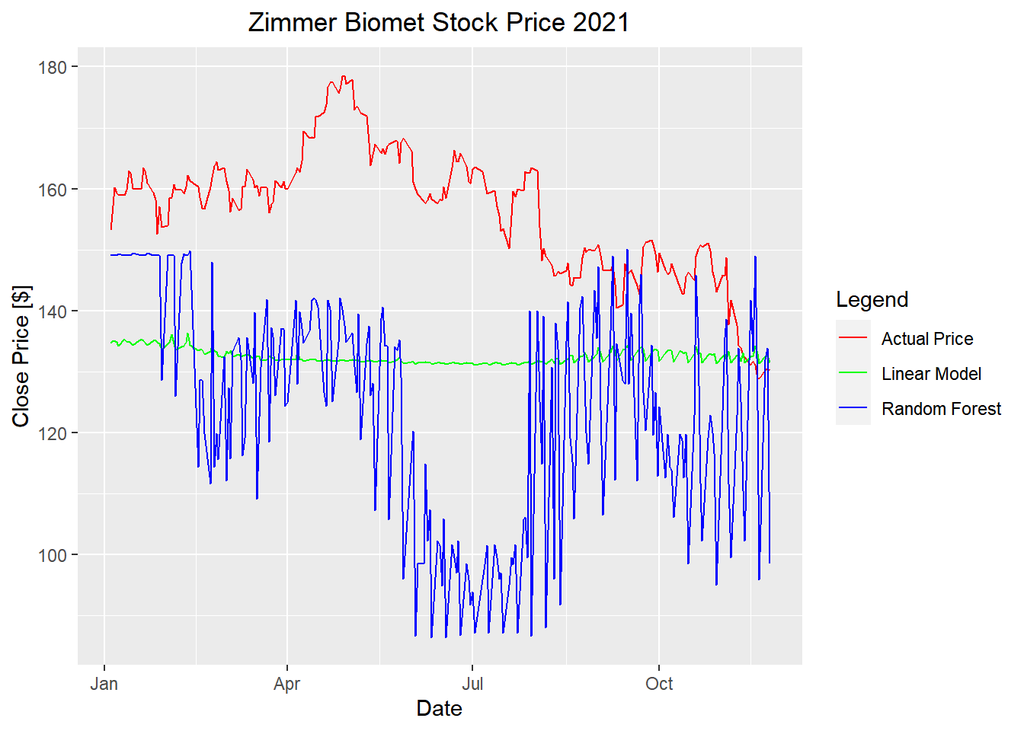

```r
ggplot()+
   geom_line(aes(Date,Close,group=1, color ="Actual Price"),data=ZBH_2021_death )+geom_line(aes(Date,LPredict,group=1, color = "Linear Model"),data=ZBH_2021_death)+geom_line(aes(Date,RfPredict,group=1, color =  "Random Forest"),data=ZBH_2021_death)+
  ggtitle("Zimmer Biomet Stock Price 2021") + theme(plot.title = element_text(hjust = 0.5)) + labs(x = "Date", y = "Close Price [$]",color = "Legend") + scale_color_manual(values = colors)
```

For Zimmer Biomet, the most accurate prediciton occurs at the Q3 and Q4 using the covid 19 cases and both prediction matches the distribution and movement of the stock market at this period. For the death case increase, the predict value is not accurate as the linear model just maintains at approximately $135 while the random forest given results that matches the change of the daily death change.

### Results

From these analysis and prediction, it is confident to saying that in 2020, the performance of the medical device company, such as sales, product development, or number of corresponding procedure conducted, are significantly affected by the daily cases and death rate change. It might be due to the fact that the public and the companies are still not ready for or adept to the new workflow under the influence during the Pandemic. Hospital may closed more beds and ICU for inpatient care which potentially limits the number of procedure can be conducted, limited the sales of the medical device companies. Labor shortage in hospital, PPE shortage, and city lock down may also contribute to the lost in sales for the medical device companies in 2020. Starting in the Q3 of 2020, with the decrease in cases, more positive news regarding the COVID 19 vaccine, and gradually adept to the new norm, the panic of worrying the performance for Medical device companies seems alleviate and it is more restive to the increase in covid case. This trend can be spotted in the stock price graph 2020 for all four companies during Q3 and Q4. Therefore, it might help to explain why the stock price didn’t get down at Q4 2020 and Q1 2021 as the covid cases and death rate were surging.

Except for the Zimmer Biomet Stock price with daily death increase, the stocks for all four companies shows strong significance with the changing the daily or death cases based on the data in 2020. The linear regression model and the random forest all demonstrated low RMSE value, which indicated that the correctness of the models with the linear model demonstrated less accuracy compared to the random forest model. However, predictions using both linear and random forest model did not give back accurate results than expected and deviated significantly from the actual stock prices of the four companies. I think this is because the significance of the daily cases and death change are gradually decreasing as more and more people and companies have used to the new norm and investors are more confident about the future market. Also, increasing in countrywide and global vaccination rate may also decrease the significance of the daily cases and death rate change and people may become less sensitive to the daily cases and death rate change and I think this may help to explain why the prediction results were incorrect while the models demonstrated low RMSE.

Lastly, based on the analysis and results, I think it is confident to say that cases and death rate change will not significantly affect the performance of the medical device companies unless a more contagious variant completely escapes from current COVID-19 cases. Since most of the people are used to this new norm and the world has already lived almost two years under the pandemic, the performance of the medical device market will get back to norm soon and see growth in the new future.

Limitation and uture: This study only consider the daily cases and death rate as the independent variable. Vaccination, Medicine development, or other social factors are not take into consideration. In the future, more factors, such as the vaccination rate, can be added to train the model and a more accurate model can be created for the medical device companies or interested investors used to predict their future stock price for companies in the medical device sectors during the pandemic or similar events which may happened in the future, helping to perform necessary risk management.

### Reference

[1]“Fast facts on U.S. hospitals, 2021: AHA,” American Hospital Association. [Online]. Available: https://www.aha.org/statistics/fast-facts-us-hospitals. [Accessed: 11-Dec-2021]. [2]“Yahoo Finance - Stock Market Live, quotes, Business & Finance News,” Yahoo! Finance. [Online]. Available: https://finance.yahoo.com/. [Accessed: 11-Dec-2021]. [3]“Fast facts on U.S. hospitals, 2021: AHA,” American Hospital Association. [Online]. Available: https://www.aha.org/statistics/fast-facts-us-hospitals. [Accessed: 11-Dec-2021]. [4]“Johns Hopkins Covid-19 Testing dashboard,” Coronavirus Information. [Online]. Available: https://covidinfo.jhu.edu/diagnostic-testing/testing-dashboard/. [Accessed: 11-Dec-2021].